# 🧼 Notebook 3 — Création et entraînement d’un modèle Xception avec Keras

```python
from tensorflow.keras.applications import Xception
from tensorflow.keras.layers import GlobalAveragePooling2D, Dense, Dropout, BatchNormalization
from tensorflow.keras.models import Model
from tensorflow.keras.optimizers import Adam
import tensorflow as tf

IMAGE_SIZE = (299, 299)

def create_xception_model():
    base_model = Xception(weights='imagenet', include_top=False, input_shape=(*IMAGE_SIZE, 3))
    base_model.trainable = False

    x = base_model.output
    x = GlobalAveragePooling2D()(x)
    x = BatchNormalization()(x)
    x = Dense(512, activation='relu')(x)
    x = BatchNormalization()(x)
    x = Dropout(0.5)(x)
    x = Dense(128, activation='relu')(x)
    x = BatchNormalization()(x)
    x = Dropout(0.3)(x)
    predictions = Dense(1, activation='sigmoid')(x)  # sortie binaire

    model = Model(inputs=base_model.input, outputs=predictions)
    model.compile(
        optimizer=Adam(learning_rate=1e-4),
        loss='binary_crossentropy',
        metrics=[
            'accuracy',
            tf.keras.metrics.Precision(name='precision')
        ]
    )
    return model, base_model

model, base_model = create_xception_model()
model.summary()
```

```
Model: "functional"
```

```
┏━━━━━━━━━━━━━━━━━━━━━┳━━━━━━━━━━━━━━━━━━━┳━━━━━━━━━━━━┳━━━━━━━━━━━━━━━━━━━┓
┃ Layer (type)        ┃ Output Shape      ┃    Param # ┃ Connected to      ┃
┡━━━━━━━━━━━━━━━━━━━━━╇━━━━━━━━━━━━━━━━━━━╇━━━━━━━━━━━━╇━━━━━━━━━━━━━━━━━━━┩
│ input_layer         │ (None, 299, 299,  │          0 │ -                 │
│ (InputLayer)        │ 3)                │            │                   │
├─────────────────────┼───────────────────┼────────────┼───────────────────┤
│ block1_conv1        │ (None, 149, 149,  │        864 │ input_layer[0][0] │
│ (Conv2D)            │ 32)               │            │                   │
├─────────────────────┼───────────────────┼────────────┼───────────────────┤
│ block1_conv1_bn     │ (None, 149, 149,  │        128 │ block1_conv1[0][… │
│ (BatchNormalizatio… │ 32)               │            │                   │
├─────────────────────┼───────────────────┼────────────┼───────────────────┤
│ block1_conv1_act    │ (None, 149, 149,  │          0 │ block1_conv1_bn[… │
│ (Activation)        │ 32)               │            │                   │
├─────────────────────┼───────────────────┼────────────┼───────────────────┤
│ block1_conv2        │ (None, 147, 147,  │     18,432 │ block1_conv1_act… │
│ (Conv2D)            │ 64)               │            │                   │
├─────────────────────┼───────────────────┼────────────┼───────────────────┤
│ block1_conv2_bn     │ (None, 147, 147,  │        256 │ block1_conv2[0][… │
│ (BatchNormalizatio… │ 64)               │            │                   │
├─────────────────────┼───────────────────┼────────────┼───────────────────┤
│ block1_conv2_act    │ (None, 147, 147,  │          0 │ block1_conv2_bn[… │
│ (Activation)        │ 64)               │            │                   │
├─────────────────────┼───────────────────┼────────────┼───────────────────┤
│ block2_sepconv1     │ (None, 147, 147,  │      8,768 │ block1_conv2_act… │
│ (SeparableConv2D)   │ 128)              │            │                   │
├─────────────────────┼───────────────────┼────────────┼───────────────────┤
│ block2_sepconv1_bn  │ (None, 147, 147,  │        512 │ block2_sepconv1[… │
│ (BatchNormalizatio… │ 128)              │            │                   │
├─────────────────────┼───────────────────┼────────────┼───────────────────┤
│ block2_sepconv2_act │ (None, 147, 147,  │          0 │ block2_sepconv1_… │
│ (Activation)        │ 128)              │            │                   │
├─────────────────────┼───────────────────┼────────────┼───────────────────┤
│ block2_sepconv2     │ (None, 147, 147,  │     17,536 │ block2_sepconv2_… │
│ (SeparableConv2D)   │ 128)              │            │                   │
├─────────────────────┼───────────────────┼────────────┼───────────────────┤
│ block2_sepconv2_bn  │ (None, 147, 147,  │        512 │ block2_sepconv2[… │
│ (BatchNormalizatio… │ 128)              │            │                   │
├─────────────────────┼───────────────────┼────────────┼───────────────────┤
│ conv2d (Conv2D)     │ (None, 74, 74,    │      8,192 │ block1_conv2_act… │
```

[output cut: 366 more lines]

```
├─────────────────────┼───────────────────┼────────────┼───────────────────┤
│ batch_normalizatio… │ (None, 512)       │      2,048 │ dense[0][0]       │
│ (BatchNormalizatio… │                   │            │                   │
├─────────────────────┼───────────────────┼────────────┼───────────────────┤
│ dropout (Dropout)   │ (None, 512)       │          0 │ batch_normalizat… │
├─────────────────────┼───────────────────┼────────────┼───────────────────┤
│ dense_1 (Dense)     │ (None, 128)       │     65,664 │ dropout[0][0]     │
├─────────────────────┼───────────────────┼────────────┼───────────────────┤
│ batch_normalizatio… │ (None, 128)       │        512 │ dense_1[0][0]     │
│ (BatchNormalizatio… │                   │            │                   │
├─────────────────────┼───────────────────┼────────────┼───────────────────┤
│ dropout_1 (Dropout) │ (None, 128)       │          0 │ batch_normalizat… │
├─────────────────────┼───────────────────┼────────────┼───────────────────┤
│ dense_2 (Dense)     │ (None, 1)         │        129 │ dropout_1[0][0]   │
└─────────────────────┴───────────────────┴────────────┴───────────────────┘
```

```
 Total params: 21,987,113 (83.87 MB)
```

```
 Trainable params: 1,120,257 (4.27 MB)
```

```
 Non-trainable params: 20,866,856 (79.60 MB)
```

# Entrainement du modèle

```python
EPOCHS = 10

history = model.fit(
    train_ds,
    validation_data=val_ds,
    epochs=EPOCHS
)
```

```
154/154 ━━━━━━━━━━━━━━━━━━━━ 523s 3s/step - accuracy: 0.8165 - loss: 0.4134 - precision: 0.8095 - val_accuracy: 0.9410 - val_loss: 0.2965 - val_precision: 0.9360
154/154 ━━━━━━━━━━━━━━━━━━━━ 523s 3s/step - accuracy: 0.8165 - loss: 0.4134 - precision: 0.8095 - val_accuracy: 0.9410 - val_loss: 0.2965 - val_precision: 0.9360
154/154 ━━━━━━━━━━━━━━━━━━━━ 497s 3s/step - accuracy: 0.9208 - loss: 0.1926 - precision: 0.9195 - val_accuracy: 0.9467 - val_loss: 0.1586 - val_precision: 0.9536
154/154 ━━━━━━━━━━━━━━━━━━━━ 497s 3s/step - accuracy: 0.9208 - loss: 0.1926 - precision: 0.9195 - val_accuracy: 0.9467 - val_loss: 0.1586 - val_precision: 0.9536
154/154 ━━━━━━━━━━━━━━━━━━━━ 499s 3s/step - accuracy: 0.9341 - loss: 0.1725 - precision: 0.9257 - val_accuracy: 0.9562 - val_loss: 0.1227 - val_precision: 0.9632
154/154 ━━━━━━━━━━━━━━━━━━━━ 499s 3s/step - accuracy: 0.9341 - loss: 0.1725 - precision: 0.9257 - val_accuracy: 0.9562 - val_loss: 0.1227 - val_precision: 0.9632
154/154 ━━━━━━━━━━━━━━━━━━━━ 498s 3s/step - accuracy: 0.9516 - loss: 0.1258 - precision: 0.9478 - val_accuracy: 0.9581 - val_loss: 0.1134 - val_precision: 0.9688
154/154 ━━━━━━━━━━━━━━━━━━━━ 498s 3s/step - accuracy: 0.9516 - loss: 0.1258 - precision: 0.9478 - val_accuracy: 0.9581 - val_loss: 0.1134 - val_precision: 0.9688
154/154 ━━━━━━━━━━━━━━━━━━━━ 493s 3s/step - accuracy: 0.9499 - loss: 0.1217 - precision: 0.9462 - val_accuracy: 0.9571 - val_loss: 0.1103 - val_precision: 0.9615
154/154 ━━━━━━━━━━━━━━━━━━━━ 493s 3s/step - accuracy: 0.9499 - loss: 0.1217 - precision: 0.9462 - val_accuracy: 0.9571 - val_loss: 0.1103 - val_precision: 0.9615
154/154 ━━━━━━━━━━━━━━━━━━━━ 495s 3s/step - accuracy: 0.9600 - loss: 0.1084 - precision: 0.9606 - val_accuracy: 0.9590 - val_loss: 0.1182 - val_precision: 0.9671
154/154 ━━━━━━━━━━━━━━━━━━━━ 495s 3s/step - accuracy: 0.9600 - loss: 0.1084 - precision: 0.9606 - val_accuracy: 0.9590 - val_loss: 0.1182 - val_precision: 0.9671
154/154 ━━━━━━━━━━━━━━━━━━━━ 491s 3s/step - accuracy: 0.9570 - loss: 0.1025 - precision: 0.9584 - val_accuracy: 0.9552 - val_loss: 0.1165 - val_precision: 0.9579
154/154 ━━━━━━━━━━━━━━━━━━━━ 491s 3s/step - accuracy: 0.9570 - loss: 0.1025 - precision: 0.9584 - val_accuracy: 0.9552 - val_loss: 0.1165 - val_precision: 0.9579
154/154 ━━━━━━━━━━━━━━━━━━━━ 491s 3s/step - accuracy: 0.9695 - loss: 0.0836 - precision: 0.9696 - val_accuracy: 0.9571 - val_loss: 0.1194 - val_precision: 0.9633
154/154 ━━━━━━━━━━━━━━━━━━━━ 491s 3s/step - accuracy: 0.9695 - loss: 0.0836 - precision: 0.9696 - val_accuracy: 0.9571 - val_loss: 0.1194 - val_precision: 0.9633
154/154 ━━━━━━━━━━━━━━━━━━━━ 492s 3s/step - accuracy: 0.9726 - loss: 0.0854 - precision: 0.9672 - val_accuracy: 0.9590 - val_loss: 0.1164 - val_precision: 0.9635
154/154 ━━━━━━━━━━━━━━━━━━━━ 492s 3s/step - accuracy: 0.9726 - loss: 0.0854 - precision: 0.9672 - val_accuracy: 0.9590 - val_loss: 0.1164 - val_precision: 0.9635
154/154 ━━━━━━━━━━━━━━━━━━━━ 491s 3s/step - accuracy: 0.9704 - loss: 0.0786 - precision: 0.9692 - val_accuracy: 0.9581 - val_loss: 0.1216 - val_precision: 0.9616
154/154 ━━━━━━━━━━━━━━━━━━━━ 491s 3s/step - accuracy: 0.9704 - loss: 0.0786 - precision: 0.9692 - val_accuracy: 0.9581 - val_loss: 0.1216 - val_precision: 0.9616
```

# Affichage des courbes d’entraînement (precision,loss)

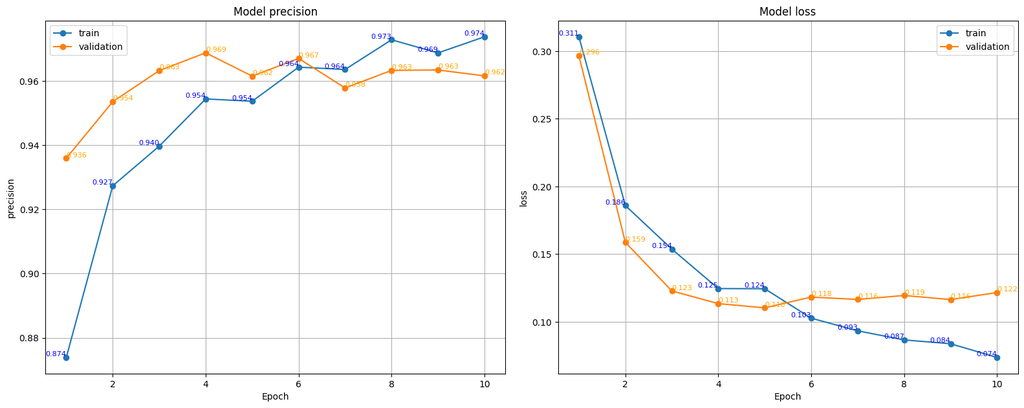

```python
import matplotlib.pyplot as plt

def plot_training_curves_with_values(history):
    metrics = ['precision', 'loss']
    plt.figure(figsize=(16, 12))
    for i, metric in enumerate(metrics):
        plt.subplot(2, 2, i+1)
        if metric == 'loss':
            train_values = history.history[metric]
            val_values = history.history['val_' + metric]
        else:
            train_values = history.history[metric]
            val_values = history.history['val_' + metric]

        epochs = range(1, len(train_values) + 1)

        plt.plot(epochs, train_values, label='train', marker='o')
        plt.plot(epochs, val_values, label='validation', marker='o')

        # Afficher les valeurs exactes sur chaque point
        for x, y in zip(epochs, train_values):
            plt.text(x, y, f'{y:.3f}', fontsize=8, color='blue', ha='right', va='bottom')
        for x, y in zip(epochs, val_values):
            plt.text(x, y, f'{y:.3f}', fontsize=8, color='orange', ha='left', va='bottom')

        plt.title(f'Model {metric}')
        plt.xlabel('Epoch')
        plt.ylabel(metric)
        plt.legend()
        plt.grid(True)
    plt.tight_layout()
    plt.show()

# Utilisation : appeler avec l'objet history retourné par model.fit
plot_training_curves_with_values(history)
```

## 📊 Analyse des courbes de précision et de loss du modèle

### Pourquoi le choix de ces deux métriques ?

La loss donne une information fine sur la progression de l’apprentissage et la capacité du modèle à ajuster ses prédictions.

La précision donne une lecture directe de la performance sur la tâche de classification, facilement compréhensible et exploitable.

Les deux sont complémentaires : la loss peut continuer à baisser même si la précision stagne, ce qui peut signaler un surapprentissage ou une optimisation trop fine sur les données d’entraînement.

On choisit la loss pour piloter l’apprentissage du modèle, et la précision pour évaluer sa performance concrète sur la tâche de classification.  
Les deux courbes sont nécessaires pour bien diagnostiquer le comportement du modèle à chaque étape de l’entraînement.

### 📈 Courbe de précision :

La précision sur le jeu d'entraînement augmente de manière continue, passant de 0.874 à l'époque 1 à 0.974 à l'époque 10.

La précision sur le jeu de validation croît rapidement au début (jusqu'à 0.969 à l'époque 4), puis elle stagne autour de 0.962 - 0.967, et montre une légère baisse sur les dernières époques.

Cela suggère un surapprentissage modéré : le modèle s'ajuste de mieux en mieux aux données d'entraînement, sans que cela améliore la performance sur les données de validation.

### 📉 Courbe de loss :

La loss d'entraînement diminue régulièrement, de 0.311 à l’époque 1 jusqu'à 0.074 à l’époque 10, ce qui montre une convergence efficace du modèle.

Ce comportement confirme le début d’un surapprentissage à partir de l’époque 6 environ, puisque le modèle devient trop spécifique à l’ensemble d’entraînement.

### 🧠 Mon hypothèse

Jusqu'à l’époque 4-5, le modèle généralise bien : les courbes de loss et de précision d'entraînement et de validation évoluent de manière similaire.

À partir de l’époque 6, la précision d'entraînement continue de monter, mais la précision de validation stagne, et la loss de validation augmente légèrement.

Ce décrochage entre les performances sur les deux ensembles indique que le modèle commence à sur-apprendre : il devient très performant sur les données connues, mais ne progresse plus sur des données nouvelles.

La précision de validation reste néanmoins élevée (environ 96%), ce qui signifie que le modèle fonctionne bien, mais il pourrait mieux généraliser.

### ✅ Recommandations et ajustements

Continuer à surveiller les courbes de loss et de précision ensemble pour ajuster dynamiquement le nombre d’époques à l’avenir.

# Matrice de Confusion et Courbe ROC

```
33/33 ━━━━━━━━━━━━━━━━━━━━ 87s 3s/step
33/33 ━━━━━━━━━━━━━━━━━━━━ 87s 3s/step
```

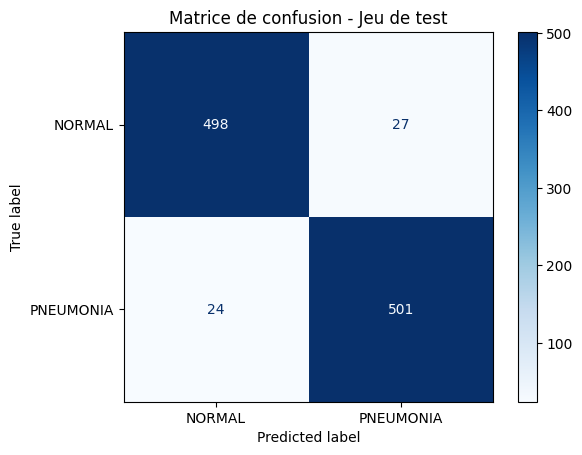

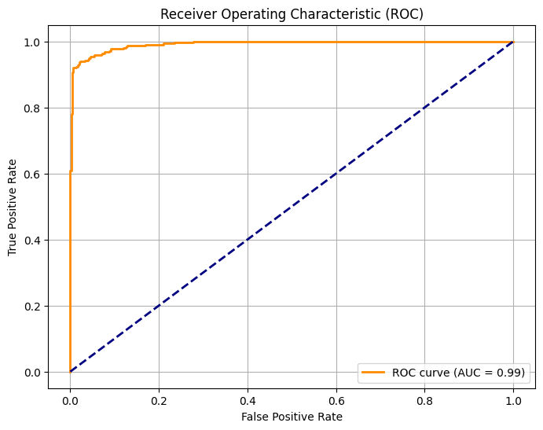

```python
import numpy as np
from sklearn.metrics import confusion_matrix, ConfusionMatrixDisplay, roc_curve, auc
import matplotlib.pyplot as plt

# Prédictions sur le dataset test (probabilités)
y_pred_prob = model.predict(test_ds)
# Binarisation avec seuil 0.5
y_pred = (y_pred_prob > 0.5).astype(int).flatten()

# Extraction des vraies étiquettes
y_true = np.concatenate([labels.numpy() for _, labels in test_ds], axis=0)

# Vérification des dimensions
assert len(y_true) == len(y_pred), "Les dimensions des vraies étiquettes et des prédictions ne correspondent pas."

# Matrice de confusion
cm = confusion_matrix(y_true, y_pred)
disp = ConfusionMatrixDisplay(confusion_matrix=cm, display_labels=class_names)
disp.plot(cmap=plt.cm.Blues)
plt.title("Matrice de confusion - Jeu de test")
plt.show()

# Courbe ROC
fpr, tpr, _ = roc_curve(y_true, y_pred_prob)
roc_auc = auc(fpr, tpr)

plt.figure(figsize=(8, 6))
plt.plot(fpr, tpr, color='darkorange', lw=2, label=f'ROC curve (AUC = {roc_auc:.2f})')
plt.plot([0, 1], [0, 1], color='navy', lw=2, linestyle='--')
plt.xlabel('False Positive Rate')
plt.ylabel('True Positive Rate')
plt.title('Receiver Operating Characteristic (ROC)')
plt.legend(loc="lower right")
plt.grid(True)
plt.show()
```

## 🧠 Choix de la matrice de confusion et de la courbe ROC

- La matrice de confusion permet de visualiser la performance du modèle en détail. Contrairement à une simple mesure d’exactitude (accuracy), elle offre une vue granulaire sur :

Les vrais positifs (TP) : ici, les cas de pneumonie bien prédits.

Les vrais négatifs (TN) : les cas normaux bien identifiés.

Les faux positifs (FP) : les cas normaux classés à tort comme pneumonie.

Les faux négatifs (FN) : les cas de pneumonie non détectés.

Cela permet de mieux évaluer les erreurs du modèle, ce qui est crucial dans des cas sensibles comme la détection de maladies (ex: éviter les faux négatifs en santé).

- La courbe ROC (Receiver Operating Characteristic) est utilisée pour évaluer les performances d’un modèle de classification binaire à différents seuils de décision. Elle trace le taux de vrais positifs (sensibilité) contre le taux de faux positifs. Son intérêt :

Elle permet de comparer plusieurs modèles indépendamment du seuil.

L’aire sous la courbe (AUC) est un indicateur global de performance :

AUC ≈ 0.5 : modèle aléatoire.

AUC = 1.0 : modèle parfait.

AUC ≥ 0.9 : modèle excellent.

📊 Interprétation des résultats de ton modèle Xception

1. Matrice de confusion

Très bonne symétrie : 498 NORMAL - 501 PNEUMONIE cas bien prédits dans chaque classe.

Seulement 24-27 erreurs pour chaque classe (faux positifs et faux négatifs).

Cela traduit un modèle équilibré, sans biais évident vers une classe.

2. Courbe ROC La courbe est proche de l’axe vertical puis horizontal, ce qui est idéal.

L’AUC = 0.99 indique une excellente capacité discriminante du modèle.

Cela signifie que dans 99% des cas, le modèle classe correctement une image aléatoire de chaque classe.

Une performance robuste avec un AUC proche de 1.

Cela confirme que le modèle est très performant pour la classification binaire entre les cas de pneumonie et les cas normaux.

# GradCam HeatMap

```
Image PNEUMONIA sélectionnée : dataset/test/PNEUMONIA\person1265_bacteria_3223.jpeg
Image NORMAL sélectionnée : dataset/test/NORMAL\aug_1360_flip_NORMAL2-IM-1274-0001.jpeg
1/1 ━━━━━━━━━━━━━━━━━━━━ 1s 873ms/step
1/1 ━━━━━━━━━━━━━━━━━━━━ 1s 873ms/step
Image : person1265_bacteria_3223.jpeg
Prédiction : PNEUMONIA avec une probabilité de 99.98%
Image : person1265_bacteria_3223.jpeg
Prédiction : PNEUMONIA avec une probabilité de 99.98%
```

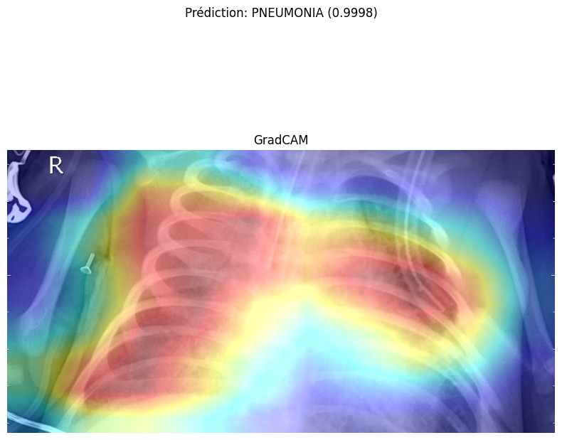

```
1/1 ━━━━━━━━━━━━━━━━━━━━ 0s 104ms/step
1/1 ━━━━━━━━━━━━━━━━━━━━ 0s 104ms/step
Image : aug_1360_flip_NORMAL2-IM-1274-0001.jpeg
Prédiction : NORMAL avec une probabilité de 0.02%
Image : aug_1360_flip_NORMAL2-IM-1274-0001.jpeg
Prédiction : NORMAL avec une probabilité de 0.02%
```

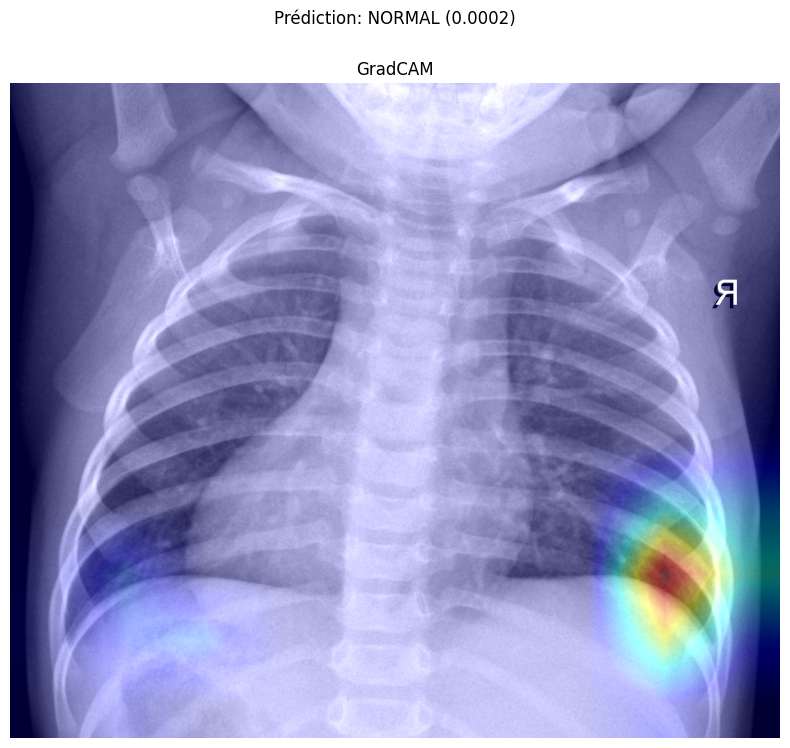

```python
import os
import random
import tensorflow as tf
import numpy as np
import matplotlib.pyplot as plt
import cv2
from tensorflow.keras.preprocessing import image
from IPython.display import display, Image as IPImage

# --- Fonctions Grad-CAM ---

def get_img_array(img_path, size):
    img = image.load_img(img_path, target_size=size)
    array = image.img_to_array(img)
    array = np.expand_dims(array, axis=0)
    return tf.keras.applications.xception.preprocess_input(array)

def make_gradcam_heatmap(img_array, model, last_conv_layer_name, pred_index=None):
    grad_model = tf.keras.models.Model(
        [model.inputs],
        [model.get_layer(last_conv_layer_name).output, model.output]
    )
    with tf.GradientTape() as tape:
        conv_outputs, predictions = grad_model(img_array)
        if pred_index is None:
            pred_index = tf.argmax(predictions[0])
        class_channel = predictions[:, pred_index]

    grads = tape.gradient(class_channel, conv_outputs)
    pooled_grads = tf.reduce_mean(grads, axis=(0, 1, 2))
    conv_outputs = conv_outputs[0]
    heatmap = conv_outputs @ pooled_grads[..., tf.newaxis]
    heatmap = tf.squeeze(heatmap)
    heatmap = tf.maximum(heatmap, 0) / tf.math.reduce_max(heatmap)
    return heatmap.numpy()

def display_gradcam(img_path, heatmap, pred_class=None, pred_value=None, alpha=0.4):
    img = cv2.imread(img_path)
    heatmap_resized = cv2.resize(heatmap, (img.shape[1], img.shape[0]))
    heatmap_uint8 = np.uint8(255 * heatmap_resized)
    heatmap_color = cv2.applyColorMap(heatmap_uint8, cv2.COLORMAP_JET)
    superimposed_img = heatmap_color * alpha + img
    superimposed_img = np.clip(superimposed_img, 0, 255).astype(np.uint8)

    plt.figure(figsize=(8,8))
    plt.imshow(cv2.cvtColor(superimposed_img, cv2.COLOR_BGR2RGB))
    plt.title('GradCAM')
    plt.axis('off')

    if pred_class is not None and pred_value is not None:
        plt.suptitle(f'Prédiction: {pred_class} ({pred_value:.4f})')

    plt.tight_layout()
    plt.show()


def get_random_image_from_class(class_dir):
    images = [os.path.join(class_dir, f) for f in os.listdir(class_dir)
              if f.lower().endswith(('.png', '.jpg', '.jpeg'))]
    return random.choice(images)

pneumonia_dir = "dataset/test/PNEUMONIA"
normal_dir = "dataset/test/NORMAL"

random_pneumonia_img = get_random_image_from_class(pneumonia_dir)
random_normal_img = get_random_image_from_class(normal_dir)

print("Image PNEUMONIA sélectionnée :", random_pneumonia_img)
print("Image NORMAL sélectionnée :", random_normal_img)



def process_and_show(img_path):
    img_size = (299, 299)
    img_array = get_img_array(img_path, img_size)
    last_conv_layer_name = "block14_sepconv2_act"


    preds = model.predict(img_array)
    prob = preds[0][0]
    classe = "PNEUMONIA" if prob > 0.5 else "NORMAL"
    print(f"Image : {os.path.basename(img_path)}")
    print(f"Prédiction : {classe} avec une probabilité de {prob*100:.2f}%")


    heatmap = make_gradcam_heatmap(img_array, model, last_conv_layer_name)
    display_gradcam(img_path, heatmap, pred_class=classe, pred_value=prob)


process_and_show(random_pneumonia_img)


process_and_show(random_normal_img)
```

```python
import os

os.makedirs('modeles', exist_ok=True)

model.save('modeles/model_initial.keras')
print("Modèle sauvegardé dans le dossier 'modeles'.")
```

```
Modèle sauvegardé dans le dossier 'modeles'.
```